# LiDAR-based scaling analysis

## Empirical scaling versus predicted symmetric exponents

Below is a plot of scaling exponents of single trees across the entire dataset. ‘Empirical’ scaling values along the y-axis are computed via SMA regressions of subtree volume against the distal number of tips, which is the essence of understanding how networks supply service volumes by scaling conduits downward in size. ‘WBE’ scaling values are computed using the symmetric formula for theta, where whole-tree alpha and beta values are taken as averages of node-level alpha and beta values.

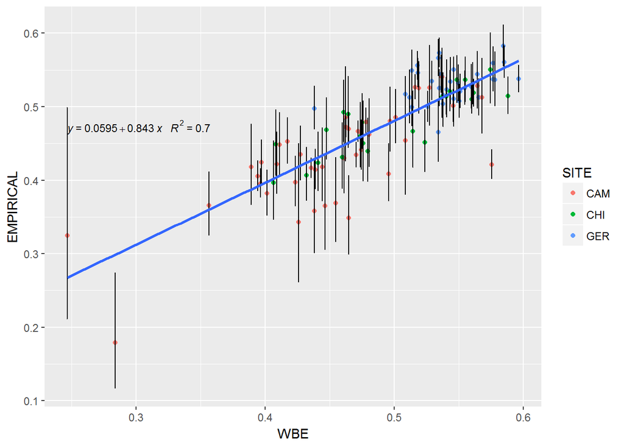

To compute the symmetric exponent using a closed form solution, we estimated the total number of branching generations for a given network, N, as log(T)/log(2), where T is the number of terminal elements in the tree. All scaling theories assume an infinitely large network, and so we see that ‘larger’ trees tend to approach optimal scaling as well:

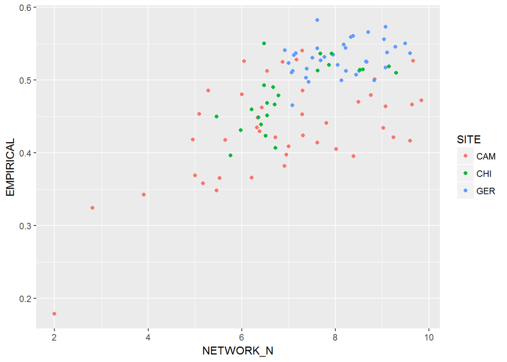

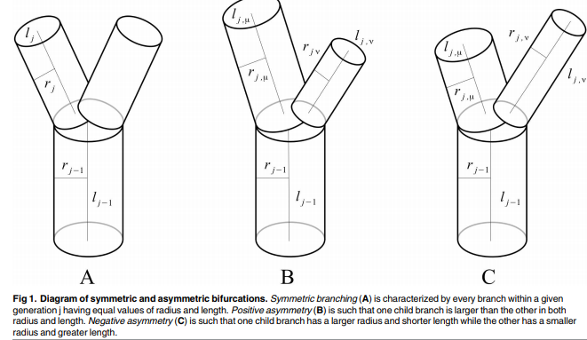

Two types of asymmetry at the node-level. Figure from Brummer et al 2017

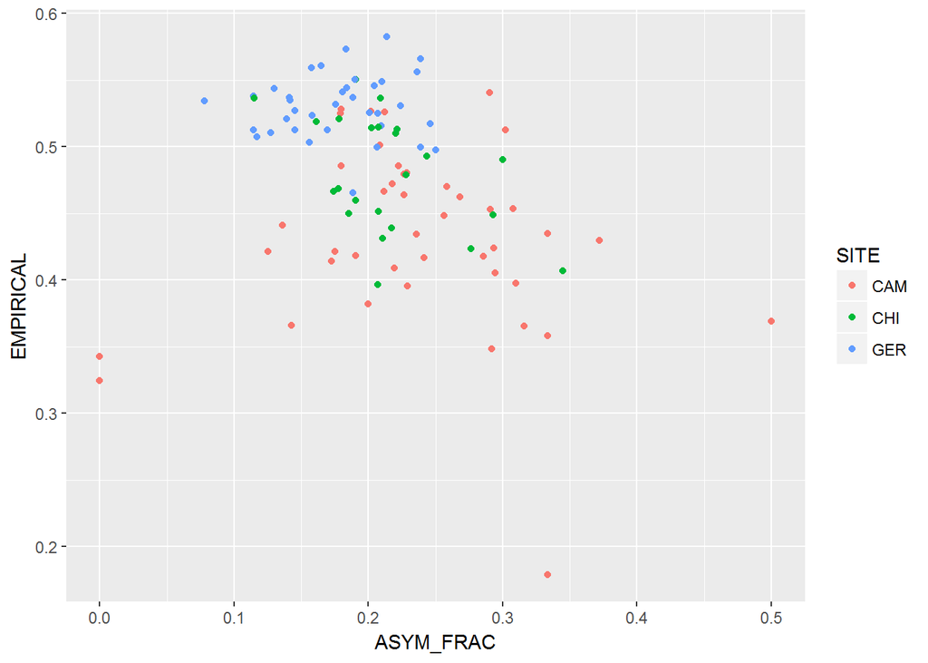

There is reason to believe that plant networks, particularly external architecture represented by branching architecture, should display the highest proportion of negative asymmetry among biological networks. Plant crowns are continually exposed to environmental heterogeneity, causing pruning through a variety of external (disturbance) and internal (shedding) mechanisms. This pruning is routinely accompanied by dynamic resprouting via axillary meristem activation.

A heuristic measure of asymmetry, path fraction (Devaud-Smith et al 2014) has been shown to capture some of the functional consequences of deviation from theoretically optimal scaling parameters. Here we show the asymmetry proportion against path fraction measured as the average path length in a tree, divided my the maximum length (Avg L) / (Max L):

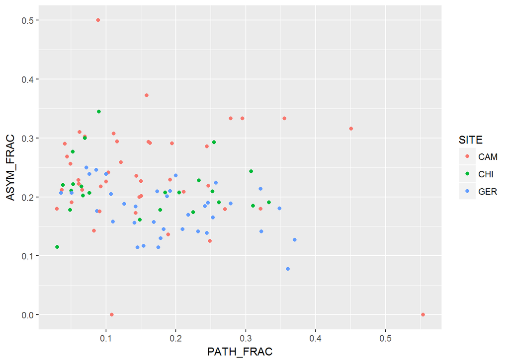

Clearly the path fraction is not very sensitive to differences in positive and negative asymmetry. Moreover, it does not predict variation in empirical scaling as successfully as the asymmetry fraction:

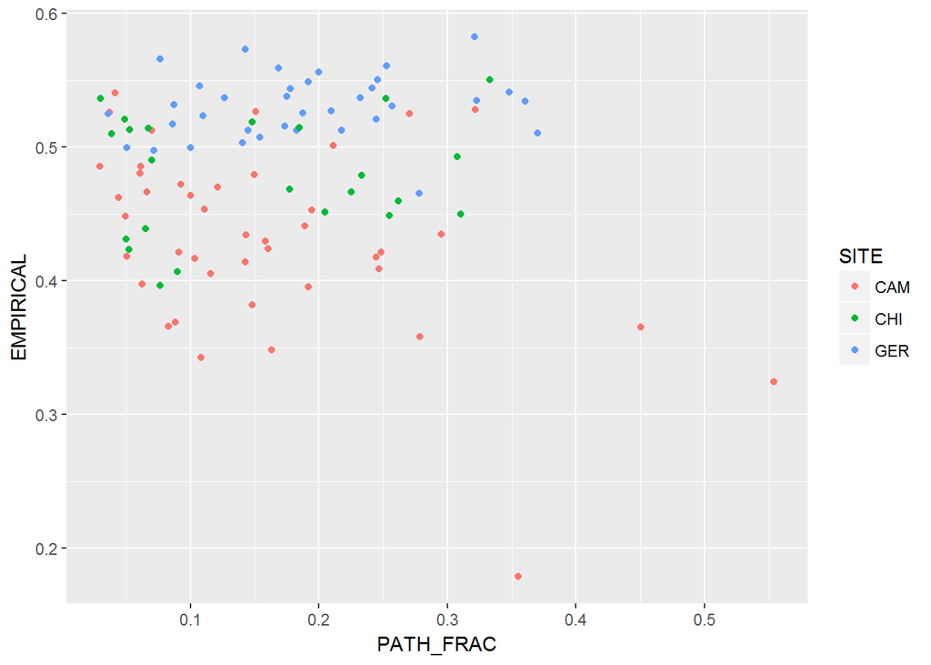

This indicates the importance of negative asymmetry in driving scaling patterns across tree species, and may lead to new insights constraining plant form and function.

Despite the limitations of the symmetrical exponent, scaling results accord generally with the expectations of functional constraints on vascular architecture. Below is a plot of symmetric scaling exponents against wood density, with mean trait values at the genus or family level when species data is missing from the BIEN database:

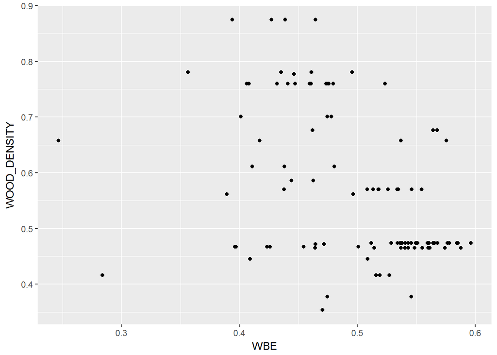

Wood density generally decreases as trees get closer to 3/4 scaling. This is likely due to biomechanical constraints.

Below is a similar plot of leaf area against the predicted symmetric exponent

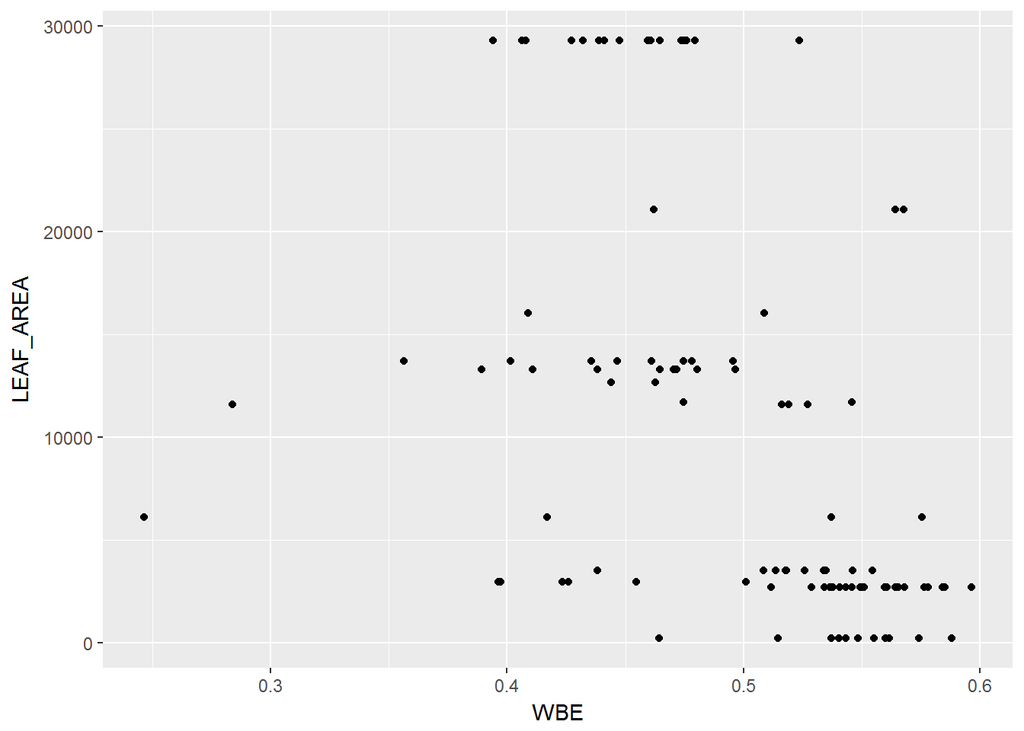

Leaf area tends to decrease as trees get closer to 3/4 scaling, which would likely also correspond to twig size and petiole radius. This broadly agrees with the body of knowledge surrounding Corner’s Rules.